# Article Analysis Notebook

Maria C. Codlin

# Introduction

In this document, I outline the reanalyis of Somerville et al. (2016), who examine the evidence for captive management of leproids at Teotihuacan, one of the earliest and largest urban centers in the Americas. Somerville et al. (2016) analysed the carbon and oxygen stable isotopes from the bone apatite of archaeological specimens from two genera of lepoids, Lepus (hares), and Sylvilagus (cottontails). Carbon is used as a proxy for human impact on the diet of these animals: higher δ13C apatite ratios imply an larger component of the diet was made up by human cultivated C4 or CAM plants such as maize. They incorperate the stable carbon isotope analysis with stable oxygen isotope analysis, as δO18 apatite ratios can be used in this context as a proxy for local humidity, providing a measure of control over environmental changes that might have influence baseline signatures of δ13C.

Their dataset (S2) contains the carbon and isotope ratios from five different parts of the city, some of which overlap slightly in period of occupation. The Moon Pyramid, Teopancazco and Oztoyahualco sites are the three that cover the classic period (150BC-550AD) occupation of Teotihuacan, and overlap somewhat in their occupation ranges. Puerta 5 and Cuevas (here Tunels y Cuevas), refer respectively to the epi-classic (600-1150AD) and post-classic (Aztec, 1150-1500AD) periods of occupation at the site. They also analysed a sample of “modern” (1892-1966AD) comparative specimens from the Basin of Mexico (S1), although these were not taken from Teotihuacan valley, they should be fairly representative of the recent agricultural landscape in the area.

As previous research had indicated the neighborhood of Ozotoyahualco might have specialised in raising cottontail rabbits, Somerville et al. (2016) hypothesised that this site would have a higher δ13C than other parts of the city. Similarly, due to previous research on urban provisioning and the declining prevalence of deer in the region during the classic period, they hypothesised that management of small animals such as leproids would become more important over time, and that this should be associated with an increase in δ13C across the sites during Teotihuacan’s classic period occupation. Finally, due to certain biological and behavioural differences between Lepus and Sylvilagus, the authors hypotheses that while both may have been managed by humans, Sylvilagus would be more suitable to captive management in an urban center, and thus would likely have a higher δ13C than Lepus.

### Outline of their project and my replication

In their analysis, they perform a variety of descriptive and interpretive analyses, as well as vizualisation of the data. I plan to replicate all of their tests.

1. Load and clean data to remove outliers and any samples that failed their quality check
2. Test for statistical differences between genera by calculating simple descriptive statistics and analysis with students T-test.
3. Two analysis of variance tests to evaluate the effect of genus and site on δ13C and δ18O as well as potential for interaction effects between genus and site.
4. After genus was found to have no effect, the analysis focused on site. They performed a one-way ANOVA and a post-hoc Tukey test on each of δ13C and δ18O to assess which sites had an effect on the two variables. One site was found to have a sigificant effect on δ13C, so a Mann-Whitney-U (two sample Wilcox rank sum test) test was employed to compare the means of that one site to the remainder of the sample.
5. The final step was visualising the data in a scatterplot of the means and standard deviation of each site for the two main variables (δ13C and δ18O) and two boxplots grouped by site. In this step they interpret ideas about how δ13C increased over time at Teotihuacan, and use Pearson’s test for correlation between the two variables to rule out environmental causes for the interpretations about δ13C.

### Introduction to this document, the contents, and the article.

First I modified the files slightly to import with curl, as it refused to bring in the header names with certain symbols in (it worked fine importing from local repo).

To start with a blank slate

```r
rm(list=ls())
```

# Step 1. Load packages and data

Before I run any parts of the analysis, I load all the packages I use in this file

```r
require(dplyr)
require(ggplot2)
require(stringr)
require(plotrix) #to calculate standard error
require(qwraps2)
require(tidyr)
require(stargazer)
require(knitr)
```

First in excel, I deleted two rows of non-table data, i.e. title, and a note, and saved the file (S2_Table) as a CSV in the project directory. Then I read it into R and converted it to a table using dplyr. I trimed white space at beginnings and ends of things where there shouldn’t be any, and kept strings as is to avoid issues later down the line.

```r
library(curl)
f <- curl("https://raw.githubusercontent.com/mazattack/Article-analysis/master/S2_Table.csv")
iso_total <- read.csv(f, header = TRUE, stringsAsFactors = FALSE, strip.white=TRUE)
```

```r
iso_total<-tbl_df(iso_total)
head(iso_total)
```

| X.U.FEFF.AS.Lab.. | Spec.or.Tag.. | Site | Unit.Project | Provenience.Location.A | Provenience.Location.B | Phase | Genus | Species | Element | Side | d13C.apatite.VPDB.... | d18O.apatite.VSMOW.... | C.P | IR.SF | Notes |
| --- | --- | --- | --- | --- | --- | --- | --- | --- | --- | --- | --- | --- | --- | --- | --- |
| AS-0315 | A-1224.001 | Moon Pyramid | Structure 2 | Tunel | LII-LIII | Patlachique-Tlamimilolpa | Lepus |  | Femur | R | -9.1 | 29.9 | NA | NA |  |
| AS-0321 | A-1955.002 | Moon Pyramid | Structure 1 | Tunel 3 | LXXIX, LXXX | Patlachique-Tlamimilolpa | Sylvilagus |  | Femur | R | -8.9 | 29.2 | 0.30 | 2.80 |  |
| AS-0322 | A-1985.002 | Moon Pyramid | Structure 1 | Tunel 3 | LXXIX y LXXX | Patlachique-Tlamimilolpa | Sylvilagus |  | Tibia | L | -10.6 | 27.3 | 0.21 | 3.04 |  |
| AS-0323 | A-1592.001 | Moon Pyramid | Structure 1 | Tunel 3 | LVI y LXXIX | Patlachique-Tlamimilolpa | Sylvilagus |  | Femur |  | -8.8 | 24.8 | 0.18 | 3.06 |  |
| AS-0324 | A-1917.001 | Moon Pyramid | Structure 1 | Tunel 3 | LXXIX y LXXX | Patlachique-Tlamimilolpa | Lepus |  | Femur | L | -5.8 | 27.1 | 0.15 | 3.17 |  |
| AS-0325 | A-1955.001 | Moon Pyramid | Structure 1 | Tunel 3 | LXXIX, LXXX | Patlachique-Tlamimilolpa | Sylvilagus |  | Tibia |  | -8.9 | 28.5 | 0.20 | 3.02 |  |

```r
str(iso_total)
```

```
Classes ‘tbl_df’, ‘tbl’ and 'data.frame':   136 obs. of  16 variables:
 $ X.U.FEFF.AS.Lab..     : chr  "AS-0315" "AS-0321" "AS-0322" "AS-0323" ...
 $ Spec.or.Tag..         : chr  "A-1224.001" "A-1955.002" "A-1985.002" "A-1592.001" ...
 $ Site                  : chr  "Moon Pyramid" "Moon Pyramid" "Moon Pyramid" "Moon Pyramid" ...
 $ Unit.Project          : chr  "Structure 2" "Structure 1" "Structure 1" "Structure 1" ...
 $ Provenience.Location.A: chr  "Tunel" "Tunel 3" "Tunel 3" "Tunel 3" ...
 $ Provenience.Location.B: chr  "LII-LIII" "LXXIX, LXXX" "LXXIX y LXXX" "LVI y LXXIX" ...
 $ Phase                 : chr  "Patlachique-Tlamimilolpa" "Patlachique-Tlamimilolpa" "Patlachique-Tlamimilolpa" "Patlachique-Tlamimilolpa" ...
 $ Genus                 : chr  "Lepus" "Sylvilagus" "Sylvilagus" "Sylvilagus" ...
 $ Species               : chr  "" "" "" "" ...
 $ Element               : chr  "Femur" "Femur" "Tibia" "Femur" ...
 $ Side                  : chr  "R" "R" "L" "" ...
 $ d13C.apatite.VPDB.... : num  -9.1 -8.9 -10.6 -8.8 -5.8 -8.9 -6.4 -9.2 -9.9 -10.3 ...
 $ d18O.apatite.VSMOW....: num  29.9 29.2 27.3 24.8 27.1 28.5 25.4 26.1 27.6 27.3 ...
 $ C.P                   : num  NA 0.3 0.21 0.18 0.15 0.2 0.15 0.11 NA 0.2 ...
 $ IR.SF                 : num  NA 2.8 3.04 3.06 3.17 3.02 3.09 3.09 NA 2.78 ...
 $ Notes                 : chr  "" "" "" "" ...
```

```r
f <- curl("https://raw.githubusercontent.com/mazattack/Article-analysis/master/S1_Table.csv")
modern<-read.csv(f, header=TRUE, sep = ",", skip=0, strip.white=TRUE, stringsAsFactors = FALSE) #here I used skip=3 to skip the first 3 rows before the data started
modern<-tbl_df(modern)
head(modern)
```

| Lab_num | Cat_num | Species | State | Location | Biome | Ecoregion | Elev..m. | Collection.date..yrs.AD. | X13C.apatite.VPDB | X18O.apatite.VSMOW |
| --- | --- | --- | --- | --- | --- | --- | --- | --- | --- | --- |
| AS-0655 | 50078 | Sylvilagus floridanus orizabae | Distrito Federal | Tlalpan | Tropical and Subtropical Coniferous Forests | Trans-Mexican Volcanic Belt pine-oak forests | 2438 | 1892 | -11.7 | 26.7 |
| AS-0656 | 50079 | Sylvilagus floridanus orizabae | Distrito Federal | Tlalpan | Tropical and Subtropical Coniferous Forests | Trans-Mexican Volcanic Belt pine-oak forests | 2316 | 1892 | -13.6 | 24.6 |
| AS-0657 | 51111 | Sylvilagus floridanus orizabae | Distrito Federal | Tlalpan | Tropical and Subtropical Coniferous Forests | Trans-Mexican Volcanic Belt pine-oak forests | 2316 | 1892 | -12.8 | 24.7 |
| AS-0660 | 55592 | Sylvilagus floridanus orizabae | Hidalgo | Tulancingo | Deserts and Xeric Shrublands | Meseta Central matorral | 2393 | 1893 | -8.4 | 25.5 |
| AS-0661 | 55599 | Sylvilagus floridanus orizabae | Hidalgo | Tulancingo | Deserts and Xeric Shrublands | Meseta Central matorral | 2591 | 1893 | -14.3 | 23.4 |
| AS-0677 | 78468 | Lepus californicus texianus | Queretaro | Tesquisquiapam | Deserts and Xeric Shrublands | Central Mexican Matorral | 1981 | 1896 | -10.2 | 27.5 |

```r
str(modern)
```

```
Classes ‘tbl_df’, ‘tbl’ and 'data.frame':   13 obs. of  11 variables:
 $ Lab_num                 : chr  "AS-0655" "AS-0656" "AS-0657" "AS-0660" ...
 $ Cat_num                 : int  50078 50079 51111 55592 55599 78468 81463 81528 540914 540914 ...
 $ Species                 : chr  "Sylvilagus floridanus orizabae" "Sylvilagus floridanus orizabae" "Sylvilagus floridanus orizabae" "Sylvilagus floridanus orizabae" ...
 $ State                   : chr  "Distrito Federal" "Distrito Federal" "Distrito Federal" "Hidalgo" ...
 $ Location                : chr  "Tlalpan" "Tlalpan" "Tlalpan" "Tulancingo" ...
 $ Biome                   : chr  "Tropical and Subtropical Coniferous Forests" "Tropical and Subtropical Coniferous Forests" "Tropical and Subtropical Coniferous Forests" "Deserts and Xeric Shrublands" ...
 $ Ecoregion               : chr  "Trans-Mexican Volcanic Belt pine-oak forests" "Trans-Mexican Volcanic Belt pine-oak forests" "Trans-Mexican Volcanic Belt pine-oak forests" "Meseta Central matorral" ...
 $ Elev..m.                : int  2438 2316 2316 2393 2591 1981 1890 1890 2075 2075 ...
 $ Collection.date..yrs.AD.: int  1892 1892 1892 1893 1893 1896 1896 1896 1966 1966 ...
 $ X13C.apatite.VPDB       : num  -11.7 -13.6 -12.8 -8.4 -14.3 -10.2 -11.9 -10.8 -14 -12.8 ...
 $ X18O.apatite.VSMOW      : num  26.7 24.6 24.7 25.5 23.4 27.5 27 26.5 26.1 25.6 ...
```

To make life easier, I changed the names of two key variables. First I tried 18O and 13C as the variable names, but it threw me an error, I think by starting with a number.

```r
names(iso_total)[12]<-"C13ap" #I used names(iso_total) to get the position of these for renaming
names(iso_total)[13]<-"O18ap"
names(iso_total)[1]<-"lab_n"
names(modern)[10]<-"modC13"
names(modern)[11]<-"modO18"
```

# Step 2: Remove of samples potentially affected by diagenisis and summarize data to check against means presented in the article

In this article, they tested a random sample (n=101) of bone for potential post-depositional alteration to the mineral structure.Using FTIR, they tested the carbonate to phospate ratios (C/P) and infrared splitting factor (IR-SF) using FTIR and removed samples which fell outside of the expected ranges of 0.1 and 0.5 for C/P and 2.0 and 4.0 for IR-SF. The samples that they removed are marked in grey in the supplimentary data.

Here, I used the filter function to select only those rows where C/P and IR-SF fell within the expected ranges, and saved this as a new dataset “iso”. I also needed to make sure the rows with NA values were still included, since only a random sample was analysed. I did this using the | notation which functions like “OR”. Since the FTIR analysis returned both C/P and IR-SF values, I only need to include one is.na function here. I also excluded an outlier with an extremely low delta O18 that they excluded by converting this number to NA, as the samples delta C13 value was still incorperated in the analysis.

```r
#to filter out only Lepus and Sylvilagus genus, I first needed to define the column as a factor
iso_total$Genus<-as.factor(iso_total$Genus)
iso<-filter(iso_total, (Genus=="Lepus" | Genus=="Sylvilagus") & between (C.P, 0.1, 0.5)&between (IR.SF, 2.0, 4.0) | (is.na(IR.SF))) #brackets around the Genus filter were important here, otherwise the | worked on everything that came after
iso$O18ap[iso$O18ap==11.9]<-NA #couldn't figure out how to get this to work with dplyr or chaining
iso
```

| lab_n | Spec.or.Tag.. | Site | Unit.Project | Provenience.Location.A | Provenience.Location.B | Phase | Genus | Species | Element | Side | C13ap | O18ap | C.P | IR.SF | Notes |
| --- | --- | --- | --- | --- | --- | --- | --- | --- | --- | --- | --- | --- | --- | --- | --- |
| AS-0315 | A-1224.001 | Moon Pyramid | Structure 2 | Tunel | LII-LIII | Patlachique-Tlamimilolpa | Lepus |  | Femur | R | -9.1 | 29.9 | NA | NA |  |
| AS-0321 | A-1955.002 | Moon Pyramid | Structure 1 | Tunel 3 | LXXIX, LXXX | Patlachique-Tlamimilolpa | Sylvilagus |  | Femur | R | -8.9 | 29.2 | 0.30 | 2.80 |  |
| AS-0322 | A-1985.002 | Moon Pyramid | Structure 1 | Tunel 3 | LXXIX y LXXX | Patlachique-Tlamimilolpa | Sylvilagus |  | Tibia | L | -10.6 | 27.3 | 0.21 | 3.04 |  |
| AS-0323 | A-1592.001 | Moon Pyramid | Structure 1 | Tunel 3 | LVI y LXXIX | Patlachique-Tlamimilolpa | Sylvilagus |  | Femur |  | -8.8 | 24.8 | 0.18 | 3.06 |  |
| AS-0324 | A-1917.001 | Moon Pyramid | Structure 1 | Tunel 3 | LXXIX y LXXX | Patlachique-Tlamimilolpa | Lepus |  | Femur | L | -5.8 | 27.1 | 0.15 | 3.17 |  |
| AS-0325 | A-1955.001 | Moon Pyramid | Structure 1 | Tunel 3 | LXXIX, LXXX | Patlachique-Tlamimilolpa | Sylvilagus |  | Tibia |  | -8.9 | 28.5 | 0.20 | 3.02 |  |
| AS-0326 | A-1962.001 | Moon Pyramid | Structure 1 | Tunel 3 | LXXIX, LXXX | Patlachique-Tlamimilolpa | Lepus |  | Femur | L | -6.4 | 25.4 | 0.15 | 3.09 |  |
| AS-0327 | A-1962.002 | Moon Pyramid | Structure 1 | Tunel 3 | LXXIX, LXXX | Patlachique-Tlamimilolpa | Sylvilagus |  | Femur | R | -9.2 | 26.1 | 0.11 | 3.09 |  |
| AS-0328 | A-1962.003 | Moon Pyramid | Structure 1 | Tunel 3 | LXXIX, LXXX | Patlachique-Tlamimilolpa | Sylvilagus |  | Femur | L | -9.9 | 27.6 | NA | NA |  |
| AS-0329 | A-1962.004 | Moon Pyramid | Structure 1 | Tunel 3 | LXXIX, LXXX | Patlachique-Tlamimilolpa | Sylvilagus |  | Tibia | R | -10.3 | 27.3 | 0.20 | 2.78 |  |

[output cut: 111 more lines]

```r
iso<-filter(iso, !(is.na(iso$Genus))) #removes empty rows
```

**Descriptive statistics from the article** Archaological specimens: δ13Capatite = -7.8 ± 2.4‰(N = 114, 1 S.D.) and δ18Oapatite = 26.0‰(N = 113, 1 S.D.). Modern reference specimens: δ13Capatite = -12.4 ± 1.8‰(N = 13, 1 S.D.) and δ18Oapatite = 26.1‰± 1.4 (N = 13, 1 S.D.).“(Somerville et al. 2016:10). *I also note that they should have used “n” here*

Note: the first time I tried this it was not a match and so I realised I needed to keep the na values in the filter above. The second time it was also not correct so I added two lines to count the number of values in the two columns of interest to see if the sample sizes match. I noted the single value from delta O18 to remove but I still have one extra row in there than their sample number. I checked on the excel, and there is no evidence of this extra row that they excluded. I took a guess that this may have been a species listed in the spreadsheet as Lepus? and removal of this specimen now produces averages that match the data presented in the article.

```r
my_sum <-
  list("Archaeological samples" =
        round (c("δC13 n" = sum(!is.na(iso$C13ap)),
              "δC13 mean" =  mean(iso$C13ap, na.rm=TRUE),
              "δC13 sd" =  sd(iso$C13ap, na.rm=TRUE),
              "δO18 n" = sum(!is.na(iso$O18ap)),
              "δO18 mean" =  mean(iso$O18ap, na.rm=TRUE),
              "δO18 sd" =  sd(iso$O18ap, na.rm=TRUE)),2),
       "Modern samples" =
         round(c("δC13 n" = sum(!is.na(modern$modC13)),
              "δC13 mean" =  mean(modern$modC13, na.rm=TRUE),
              "δC13 sd" =  sd(modern$modC13, na.rm=TRUE),
              "δO18 n" = sum(!is.na(modern$modO18)),
              "δO18 mean" =  mean(modern$modO18, na.rm=TRUE),
              "δO18 sd" =  sd(modern$modO18, na.rm=TRUE)),2)
       )

my_sum
```

```
$`Archaeological samples`
   dC13 n dC13 mean   dC13 sd    dO18 n dO18 mean   dO18 sd
   114.00     -7.75      2.34    113.00     26.01      2.19

$`Modern samples`
   dC13 n dC13 mean   dC13 sd    dO18 n dO18 mean   dO18 sd
    13.00    -12.39      1.80     13.00     26.08      1.40
```

# Step 3 “Independent samples t-tests were conducted to compare mean stable isotope ratios of the two genera (Lepus and Sylvilagus) across the archaeological bone sample as a whole. No significant difference between the genera were found in δ13Capatite values (t[110] = -0.806, p = 0.422) or δ18Oapatite values (t[110] = 0.428, p = 0.669).”

First, I will check that the data fits a normal distribution by comparing it to the qnorm and qqline plots as well as histogram.

**Carbon Apatite Results** *Histogram*

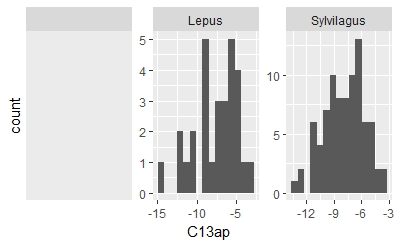

```r
a_hist<-ggplot(iso, aes(C13ap))
a_hist+geom_histogram(bins= 15)+ facet_wrap(~Genus, scales="free")
```

Sylvilagus looks approximately normal while Lepus it is hard to tell. Next I compare using qqplots. *QQplots*

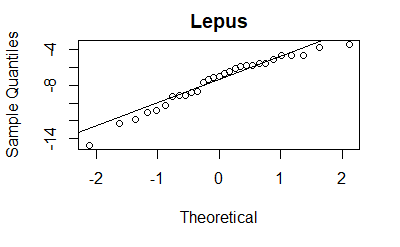

```r
LC<-iso$C13ap[iso$Genus=="Lepus"]
SC<-iso$C13ap[iso$Genus=="Sylvilagus"]
qqnorm(LC,xlab="Theoretical",main="Lepus")
  qqline(LC)
```

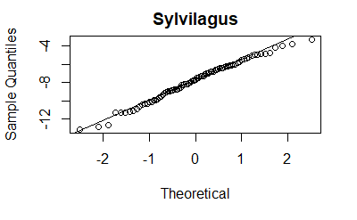

```r
  qqnorm(SC,xlab="Theoretical",main="Sylvilagus")
  qqline(SC)
```

```r
  shapiro.test(LC)
```

```
    Shapiro-Wilk normality test

data:  LC
W = 0.94867, p-value = 0.169
```

```r
  shapiro.test(SC)
```

```
    Shapiro-Wilk normality test

data:  SC
W = 0.98596, p-value = 0.4885
```

Again, Lepus fits this “OK” while Sylvilagus looks pretty good. Both samples pass the Shapiro-Wilk test for normality. *Test of equal variance*

```r
var.test(LC, SC)
```

```
    F test to compare two variances

data:  LC and SC
F = 1.6153, num df = 28, denom df = 84, p-value = 0.09787
alternative hypothesis: true ratio of variances is not equal to 1
95 percent confidence interval:
 0.9160149 3.1318232
sample estimates:
ratio of variances
          1.615282
```

This suggests that the variance of the two samples is comparable and thus a two sample T test can be used.First I report the tests for the oxygen data and then provide both t-tests together with a discussion.

**Oxygen Apatite Results** *Histogram*

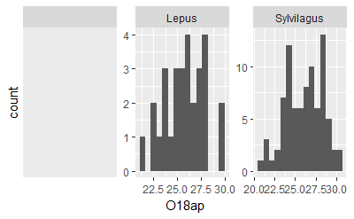

```r
a_hist<-ggplot(iso, aes(O18ap))
a_hist+geom_histogram(bins=15)+ facet_wrap(~Genus, scales="free")
```

Both look like they could be approximately normal *QQplots*

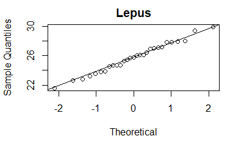

```r
LO<-iso$O18ap[iso$Genus=="Lepus"]
SO<-iso$O18ap[iso$Genus=="Sylvilagus"]
qqnorm(LO,xlab="Theoretical",main="Lepus")
  qqline(LO)
```

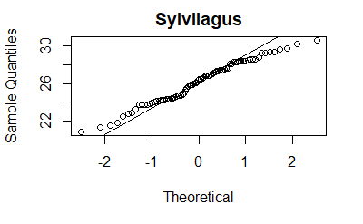

```r
  qqnorm(SO,xlab="Theoretical",main="Sylvilagus")
  qqline(SO)
```

Here, Lepus fits the normal distrbution well, while Sylvilagus is divergent. Looking at the histgram again, it could poentitally be bimodal. *Test of equal variance*

```r
var.test(LO, SO)
```

```
    F test to compare two variances

data:  LO and SO
F = 0.8248, num df = 28, denom df = 83, p-value = 0.5763
alternative hypothesis: true ratio of variances is not equal to 1
95 percent confidence interval:
 0.4671707 1.6002060
sample estimates:
ratio of variances
         0.8247966
```

*Carbon apatite two sample T-test*

```r
t.test(LC, SC, var.equal =TRUE, alternative = "two.sided")
```

```
    Two Sample t-test

data:  LC and SC
t = 0.5185, df = 112, p-value = 0.6051
alternative hypothesis: true difference in means is not equal to 0
95 percent confidence interval:
 -0.7374447  1.2602033
sample estimates:
mean of x mean of y
-7.558621 -7.820000
```

*Oxygen apatite two sample T-test*

```r
t.test(SO, LO, var.equal =TRUE, alternative = "two.sided")
```

```
    Two Sample t-test

data:  SO and LO
t = 0.83133, df = 111, p-value = 0.4076
alternative hypothesis: true difference in means is not equal to 0
95 percent confidence interval:
 -0.542769  1.327334
sample estimates:
mean of x mean of y
 26.10952  25.71724
```

Both of these tests returned different test statistics, degrees of freedom and p-values to those reported by Somerville et al. (2016). I tried multiple variations of the t-test in R, from Welsh t-test and one sided t-tests to one sided Welsh t-tests and none of the tests produced a similar result to those reported by Somerville. In fact, the two sample t-test for equal varience that I ran for both carbon and oxygen data matches most closely with the result reported for the opposite isotopic data. i.e. my oxygen looks most similar to their carbon. I have a number of hypothesis for why these tests may vary: the SPSS test is vastly different to the R t-tests, they are excluding samples from the test and not reporting it, as indicated by the difference in df between our tests, or there was an error in their reporting of the data. That said, the outcome of all tests is the same, there is no significant difference in the means of the samples. I later realised that the data they provide is slightly differerent from the results presented and this is likely the reason for the differences observed in this test. This is most clearly observed in the table below and comparison to their table 2.

# Step 4

“We also evaluated stable isotope ratios between the genera and between individual site locations using a two-way ANOVA (factorial ANOVA with two factors), testing for the main effects of genus and context, and for the genuscontext interaction.”

*Summary table (Compare Table 2)*

```r
Genus<- as.factor(modern$Species)
modern<-cbind(modern, Genus)
levels(modern$Genus)[levels(modern$Genus)=="Lepus californicus texianus"]<-"Lepus"
levels(modern$Genus)[levels(modern$Genus)=="Sylvilagus floridanus"]<-"Sylvilagus"
levels(modern$Genus)[levels(modern$Genus)=="Sylvilagus floridanus orizabae"]<-"Sylvilagus"
levels(modern$Genus)
```

```
[1] "Lepus"      "Sylvilagus"
```

```r
new<-select(iso, lab_n, Site, Phase, Genus, C13ap, O18ap)
new2<-select(modern, lab_n=Lab_num, Site=State, Phase=Collection.date..yrs.AD., Genus, C13ap=modC13, O18ap=modO18)%>%mutate(Site="modern")
iso2<-rbind(filter(new,(!(is.na(C13ap)))), new2)
iso2
```

| lab_n | Site | Phase | Genus | C13ap | O18ap |
| --- | --- | --- | --- | --- | --- |
| AS-0315 | Moon Pyramid | Patlachique-Tlamimilolpa | Lepus | -9.1 | 29.9 |
| AS-0321 | Moon Pyramid | Patlachique-Tlamimilolpa | Sylvilagus | -8.9 | 29.2 |
| AS-0322 | Moon Pyramid | Patlachique-Tlamimilolpa | Sylvilagus | -10.6 | 27.3 |
| AS-0323 | Moon Pyramid | Patlachique-Tlamimilolpa | Sylvilagus | -8.8 | 24.8 |
| AS-0324 | Moon Pyramid | Patlachique-Tlamimilolpa | Lepus | -5.8 | 27.1 |
| AS-0325 | Moon Pyramid | Patlachique-Tlamimilolpa | Sylvilagus | -8.9 | 28.5 |
| AS-0326 | Moon Pyramid | Patlachique-Tlamimilolpa | Lepus | -6.4 | 25.4 |
| AS-0327 | Moon Pyramid | Patlachique-Tlamimilolpa | Sylvilagus | -9.2 | 26.1 |
| AS-0328 | Moon Pyramid | Patlachique-Tlamimilolpa | Sylvilagus | -9.9 | 27.6 |
| AS-0329 | Moon Pyramid | Patlachique-Tlamimilolpa | Sylvilagus | -10.3 | 27.3 |

[output cut: 117 more lines]

```r
iso2$Genus <-as.factor(iso2$Genus)
iso2_g <- group_by(iso2, Site, Genus)
sum_tot<- summarize(iso2_g, length(C13ap), mean(C13ap), sd(C13ap), length(O18ap), mean(O18ap), sd(O18ap))
tot_tot<-iso2%>%
  group_by(Genus)%>%
  summarize(length(C13ap), mean(C13ap), sd(C13ap), length(O18ap), mean(O18ap), sd(O18ap))
tot_tot<-mutate(tot_tot, Site="Total")
tot<-rbind.data.frame(sum_tot, tot_tot)
tot
```

| Site | Genus | length(C13ap) | mean(C13ap) | sd(C13ap) | length(O18ap) | mean(O18ap) | sd(O18ap) |
| --- | --- | --- | --- | --- | --- | --- | --- |
| modern | Lepus | 1 | -10.200000 | NaN | 1 | 27.50000 | NaN |
| modern | Sylvilagus | 12 | -12.575000 | 1.7467502 | 12 | 25.95833 | 1.3976983 |
| Moon Pyramid | Lepus | 16 | -8.406250 | 3.1501257 | 16 | 25.14375 | 2.0886898 |
| Moon Pyramid | Sylvilagus | 34 | -8.658824 | 2.0647280 | 34 | NA | NaN |
| Oztoyahualco | Lepus | 3 | -5.000000 | 1.4177447 | 3 | 27.03333 | 2.3501773 |
| Oztoyahualco | Sylvilagus | 11 | -6.218182 | 2.3029625 | 11 | 24.94545 | 2.3526001 |
| Puerta 5 | Lepus | 2 | -6.150000 | 0.7778175 | 2 | 24.80000 | 1.8384776 |
| Puerta 5 | Sylvilagus | 19 | -7.278947 | 2.0868847 | 19 | 24.53684 | 1.5699294 |
| Teopancazco | Lepus | 4 | -6.875000 | 2.5342652 | 4 | 26.97500 | 0.9105859 |
| Teopancazco | Sylvilagus | 15 | -6.953333 | 1.1268583 | 15 | 27.56667 | 1.5723807 |

[output cut: 4 more lines]

Note the differences across these summary statistics compared to the table provided in the article (Table 2). This reflects a difference in the data from the article compared to what they provided. I checked this in excel to confirm.

```r
carbon<-lm(iso$C13ap~iso$Genus*iso$Site)
anova(carbon)#not sure why but moon pyramid is missing from all these ANOVA
```

```
Analysis of Variance Table

Response: iso$C13ap
                    Df Sum Sq Mean Sq F value   Pr(>F)
iso$Genus            1   1.48  1.4773  0.3175 0.574334
iso$Site             4 120.18 30.0446  6.4571 0.000111 ***
iso$Genus:iso$Site   4  11.34  2.8356  0.6094 0.656749
Residuals          104 483.91  4.6529
---
Signif. codes:  0 ‘***’ 0.001 ‘**’ 0.01 ‘*’ 0.05 ‘.’ 0.1 ‘ ’ 1
```

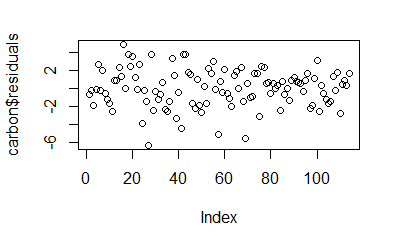

```r
plot(carbon$residuals)
```

```r
oxygen<-lm(iso$O18ap~iso$Genus*iso$Site)
summary(oxygen)
```

```
Call:
lm(formula = iso$O18ap ~ iso$Genus * iso$Site)

Residuals:
    Min      1Q  Median      3Q     Max
-4.6500 -1.2500 -0.0368  1.5303  4.7563

Coefficients:
                                             Estimate Std. Error t value Pr(>|t|)
(Intercept)                                   25.1438     0.4958  50.718   <2e-16 ***
iso$GenusSylvilagus                            1.6259     0.6041   2.692   0.0083 **
iso$SiteOztoyahualco                           1.8896     1.2476   1.515   0.1329
iso$SitePuerta 5                              -0.3437     1.4873  -0.231   0.8177
iso$SiteTeopancazco                            1.8312     1.1085   1.652   0.1016
iso$SiteTúneles y Cuevas                       1.0812     1.1085   0.975   0.3317
iso$GenusSylvilagus:iso$SiteOztoyahualco      -3.7138     1.4259  -2.605   0.0106 *
iso$GenusSylvilagus:iso$SitePuerta 5          -1.8891     1.5931  -1.186   0.2384
iso$GenusSylvilagus:iso$SiteTeopancazco       -1.0343     1.2689  -0.815   0.4169
iso$GenusSylvilagus:iso$SiteTúneles y Cuevas  -1.9009     1.4154  -1.343   0.1822
---
Signif. codes:  0 ‘***’ 0.001 ‘**’ 0.01 ‘*’ 0.05 ‘.’ 0.1 ‘ ’ 1

Residual standard error: 1.983 on 103 degrees of freedom
  (8 observations deleted due to missingness)
Multiple R-squared:  0.2445,    Adjusted R-squared:  0.1785
F-statistic: 3.704 on 9 and 103 DF,  p-value: 0.0004684
```

**One way ANOVA tests**

```r
carbon2<-lm(iso$C13ap~iso$Site)
anova(carbon2)
```

```
Analysis of Variance Table

Response: iso$C13ap
           Df Sum Sq Mean Sq F value    Pr(>F)
iso$Site    4 112.56  28.140  6.0817 0.0001866 ***
Residuals 109 504.34   4.627
---
Signif. codes:  0 ‘***’ 0.001 ‘**’ 0.01 ‘*’ 0.05 ‘.’ 0.1 ‘ ’ 1
```

```r
m <- aov(iso$C13ap~iso$Site)
summary(m)
```

```
             Df Sum Sq Mean Sq F value   Pr(>F)
iso$Site      4  112.6  28.140   6.082 0.000187 ***
Residuals   109  504.3   4.627
---
Signif. codes:  0 ‘***’ 0.001 ‘**’ 0.01 ‘*’ 0.05 ‘.’ 0.1 ‘ ’ 1
7 observations deleted due to missingness
```

```r
posthoc <- TukeyHSD(m, "iso$Site", conf.level = 0.95)
posthoc
```

```
  Tukey multiple comparisons of means
    95% family-wise confidence level

Fit: aov(formula = iso$C13ap ~ iso$Site)

$`iso$Site`
                                    diff         lwr        upr     p adj
Oztoyahualco-Moon Pyramid      2.6208571  0.81662427  4.4250900 0.0009681
Puerta 5-Moon Pyramid          1.4065714 -0.14505136  2.9581942 0.0948394
Teopancazco-Moon Pyramid       1.6411579  0.03305302  3.2492628 0.0430481
Túneles y Cuevas-Moon Pyramid -0.3420000 -2.40900843  1.7250084 0.9907453
Puerta 5-Oztoyahualco         -1.2142857 -3.27307539  0.8445040 0.4778465
Teopancazco-Oztoyahualco      -0.9796992 -3.08138499  1.1219865 0.6960159
Túneles y Cuevas-Oztoyahualco -2.9628571 -5.43340476 -0.4923095 0.0103261
Teopancazco-Puerta 5           0.2345865 -1.65468851  2.1238614 0.9969330
Túneles y Cuevas-Puerta 5     -1.7485714 -4.04114259  0.5439997 0.2209070
Túneles y Cuevas-Teopancazco  -1.9831579 -4.31432724  0.3480115 0.1344336
```

```r
group1<-(iso2) %>%
  filter(Site!="modern", Site!="Oztoyahualco") %>%
  select(C13ap)
group2<-(iso2) %>%
  filter(Site=="Oztoyahualco") %>%
  select(C13ap)
group1<-as.numeric(unlist(group1))
group2<-as.numeric(unlist(group2))
wilcox.test(group1, group2)
```

```
    Wilcoxon rank sum test with continuity correction

data:  group1 and group2
W = 339, p-value = 0.001853
alternative hypothesis: true location shift is not equal to 0
```

```r
group1<-(iso2) %>%
  filter(Site!="modern", Site!="Oztoyahualco") %>%
  select(O18ap)
group2<-(iso2) %>%
  filter(Site=="Oztoyahualco") %>%
  select(O18ap)
group1<-as.numeric(unlist(group1))
group2<-as.numeric(unlist(group2))
wilcox.test(group1, group2)
```

```
    Wilcoxon rank sum test with continuity correction

data:  group1 and group2
W = 782.5, p-value = 0.4379
alternative hypothesis: true location shift is not equal to 0
```

```r
m <- aov(iso$O18ap~iso$Site)
summary(m)
```

```
             Df Sum Sq Mean Sq F value   Pr(>F)
iso$Site      4   90.9  22.731   5.514 0.000445 ***
Residuals   108  445.2   4.122
---
Signif. codes:  0 ‘***’ 0.001 ‘**’ 0.01 ‘*’ 0.05 ‘.’ 0.1 ‘ ’ 1
8 observations deleted due to missingness
```

```r
posthoc <- TukeyHSD(m, "iso$Site", conf.level = 0.95)
posthoc
```

```
  Tukey multiple comparisons of means
    95% family-wise confidence level

Fit: aov(formula = iso$O18ap ~ iso$Site)

$`iso$Site`
                                    diff         lwr        upr     p adj
Oztoyahualco-Moon Pyramid     -0.8459184 -2.55296779  0.8611311 0.6450024
Puerta 5-Moon Pyramid         -1.6768707 -3.14606497 -0.2076765 0.0168045
Teopancazco-Moon Pyramid       1.2033298 -0.31903070  2.7256902 0.1902292
Túneles y Cuevas-Moon Pyramid -0.1787755 -2.13341129  1.7758603 0.9990725
Puerta 5-Oztoyahualco         -0.8309524 -2.77451365  1.1126089 0.7592704
Teopancazco-Oztoyahualco       2.0492481  0.06519165  4.0333046 0.0393030
Túneles y Cuevas-Oztoyahualco  0.6671429 -1.66513066  2.9994164 0.9319595
Teopancazco-Puerta 5           2.8802005  1.09666637  4.6637346 0.0001784
Túneles y Cuevas-Puerta 5      1.4980952 -0.66616299  3.6623535 0.3128666
Túneles y Cuevas-Teopancazco  -1.3821053 -3.58280138  0.8185909 0.4126923
```

*For δ13Capatite, the main effect for genus was not significant (F[1,102] = 3.361), p = 0.070), but the main effect of site context was significant (F[4,102] = 5.365, p = 0.001). Importantly, the interaction between genus and site was not significant for δ13Capatite (F[4,102] = 0.590, p<0.670) or for δ18Oapatite (F[4,102] = 0.834, p<0.507). However, Lepus and Sylvilagus values are notably different from each other at the Cuevas site, but the small sample size from this context makes any interpretations regarding this observation speculative. Subsequent contextual comparisons thus combine Sylvilagus and Lepus specimens*

# Visualing the data in graphs

gm <- iso2 %>% group_by(Site) %>% summarise(mean_C13ap = mean(C13ap), mean_O18ap = mean(O18ap, na.rm=T), C13SE=sqrt(var(C13ap))/length(C13ap), O18SE=sqrt(var(O18ap, na.rm=T))/length(O18ap))

```r
iso2$Site = factor(iso2$Site, c("Moon Pyramid", "Teopancazco", "Oztoyahualco", "Puerta 5", "Túneles y Cuevas", "modern"), labels=c("Moon Pyramid (150 BC-AD 450)", "Teopancazco (AD 200-550)", "Oztoyahualco (AD 350-550)", "Puerta 5 (AD 600-1150)", "Túneles y Cuevas (AD 1150-1500)", "modern (AD 1892-1966)"))
```

```r
gm <- iso2 %>%
        group_by(Site) %>%
        summarise(mean_C13ap = mean(C13ap),
                  mean_O18ap  = mean(O18ap, na.rm=T),
                  C13SD=sd(C13ap),
                  O18SD=sd(O18ap, na.rm=T))
gm
```

| Site | mean_C13ap | mean_O18ap | C13SD | O18SD |
| --- | --- | --- | --- | --- |
| Moon Pyramid (150 BC-AD 450) | -8.578000 | 26.23878 | 2.433716 | 2.105035 |
| Teopancazco (AD 200-550) | -6.936842 | 27.44211 | 1.434964 | 1.456905 |
| Oztoyahualco (AD 350-550) | -5.957143 | 25.39286 | 2.158245 | 2.428505 |
| Puerta 5 (AD 600-1150) | -7.171429 | 24.56190 | 2.016220 | 1.547086 |
| Túneles y Cuevas (AD 1150-1500) | -8.920000 | 26.06000 | 1.977541 | 2.784162 |
| modern (AD 1892-1966) | -12.392308 | 26.07692 | 1.797434 | 1.404845 |

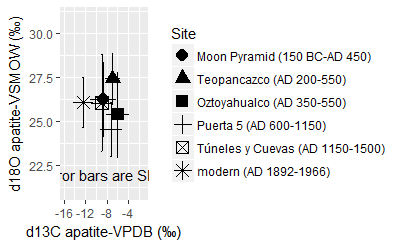

```r
g<-ggplot(gm, aes(x=mean_C13ap, y=mean_O18ap, shape = Site))
g+geom_point(data=gm, size=4)+ xlim(-16, -1) +ylim(21, 31)+
      geom_errorbarh(data = gm,aes(xmin = mean_C13ap - C13SD,xmax = mean_C13ap + C13SD,y = mean_O18ap)) +
    geom_errorbar(data = gm,aes(ymin = mean_O18ap - O18SD,ymax = mean_O18ap + O18SD,x = mean_C13ap)) +
  labs(x="δ13C apatite-VPDB (‰)", y="δ18O apatite-VSMOW (‰)") +
  annotate(geom = "text", x = -12, y = 22, label = "note error bars are SD")
```

```r
NA
```

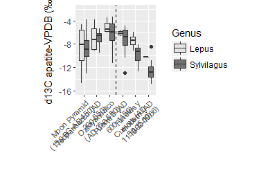

```r
g<-ggplot(iso2, aes(x=Site, y=C13ap))
g<-g+geom_boxplot(aes(fill=Genus))+
  ylim(-16, -2) +
  labs(x="" ,y="δ13C apatite-VPDB (‰)") +
  scale_color_manual(values=c("black", "black"))+
  scale_fill_manual(values=c( "grey90", "grey45"))+
  theme(axis.text.x = element_text(size=8, angle=45, hjust = 1))+
  scale_x_discrete(labels = function(x) str_wrap(x, width = 15))+
   coord_fixed(.45)+
    geom_vline(aes(xintercept = 3.5), linetype=2)
g
ggsave(filename = "carbon_box.png", g,
       width = 8, height = 9, dpi = 300, units = "in", device='png')
```

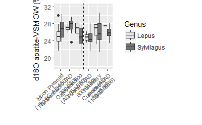

```r
g<-ggplot(iso2, aes(x=Site, y=O18ap))
g<-g+geom_boxplot(aes(fill=Genus))+
  ylim(18, 32) +
  labs(x="" ,y="δ18O apatite-VSMOW (‰)") +
  scale_color_manual(values=c("black", "black"))+
  scale_fill_manual(values=c( "grey90", "grey45"))+
  theme(axis.text.x = element_text(size=8, angle=45, hjust = 1))+
  scale_x_discrete(labels = function(x) str_wrap(x, width = 15))+
   coord_fixed(.45)+
   geom_vline(aes(xintercept = 3.5), linetype=2)
g
ggsave(filename = "oxygen_box.png", g,
       width = 8, height = 9, dpi = 300, units = "in", device='png')
```

```r
library(Hmisc)
cor.test(x=iso2$C13ap, y=iso2$O18ap, method= "pearson")
```

```
    Pearson's product-moment correlation

data:  iso2$C13ap and iso2$O18ap
t = 0.2772, df = 124, p-value = 0.7821
alternative hypothesis: true correlation is not equal to 0
95 percent confidence interval:
 -0.1506772  0.1989266
sample estimates:
       cor
0.02488555
```